# Stage2CorrelationAnalysis

该阶段主要计算和分析不同气象因素与HFMD之间的关联性。

```python
#读取气象数据
import pandas as pd
Data=pd.read_csv('/root/AnalysisData/AnalysisData.csv',parse_dates=["Date"])
Data.info()
```

```
<class 'pandas.DataFrame'>
RangeIndex: 60 entries, 0 to 59
Data columns (total 11 columns):
 #   Column             Non-Null Count  Dtype
---  ------             --------------  -----
 0   Unnamed: 0         60 non-null     int64
 1   Date               60 non-null     datetime64[us]
 2   Pressure(hPa)      60 non-null     float64
 3   RH(%)              60 non-null     float64
 4   WindSpeed(m/s)     60 non-null     float64
 5   temperature_mean   60 non-null     float64
 6   temperature_min    60 non-null     float64
 7   temperature_max    60 non-null     float64
 8   petPM(mm)          60 non-null     float64
 9   precipitation(mm)  60 non-null     float64
 10  IR                 60 non-null     float64
dtypes: datetime64[us](1), float64(9), int64(1)
memory usage: 5.3 KB
```

```python
#统计空缺数据
Data.isnull().sum()
```

```
Unnamed: 0           0
Date                 0
Pressure(hPa)        0
RH(%)                0
WindSpeed(m/s)       0
temperature_mean     0
temperature_min      0
temperature_max      0
petPM(mm)            0
precipitation(mm)    0
IR                   0
dtype: int64
```

计算气象因素与HFMD之间相关性

```python
#对数据进行正态性检验
from pandas import DataFrame
from scipy.stats import shapiro, levene
FeatureName=list(Data.columns[2:])
Feature,Stats,P_value,Clima=[],[],[],[]
for feature in FeatureName:
    data=Data.loc[:,feature]
    stats,p_value=shapiro(data)    #正态检验
    Feature.append(feature)
    Stats.append(stats)
    P_value.append(p_value)
    Clima.append(data)
Normal=DataFrame()
Normal['Feature']=Feature
Normal['Stats']=Stats
Normal['P value']=P_value
```

```python
Normal
```

|  | Feature | Stats | P value |
| --- | --- | --- | --- |
| 0 | Pressure(hPa) | 0.935369 | 3.380704e-03 |
| 1 | RH(%) | 0.981546 | 4.973474e-01 |
| 2 | WindSpeed(m/s) | 0.947434 | 1.181768e-02 |
| 3 | temperature_mean | 0.931353 | 2.267493e-03 |
| 4 | temperature_min | 0.922827 | 9.985438e-04 |
| 5 | temperature_max | 0.941634 | 6.411903e-03 |
| 6 | petPM(mm) | 0.945137 | 9.256571e-03 |
| 7 | precipitation(mm) | 0.886165 | 4.274067e-05 |
| 8 | IR | 0.764436 | 1.942308e-08 |

```python
#方差齐性检验
levene_stats,levene_pvalue=levene(*Clima)
print(f'Levene检验统计量:{levene_stats},P值:{levene_pvalue}')
```

```
Levene检验统计量:46.98688868703357,P值:4.4102459333221014e-57
```

```python
#输出正态检验结果
Normal.to_csv('/root/ToResult/Stage2CorrelationAnalysis/ClimateNormal.csv',encoding='utf-8')
```

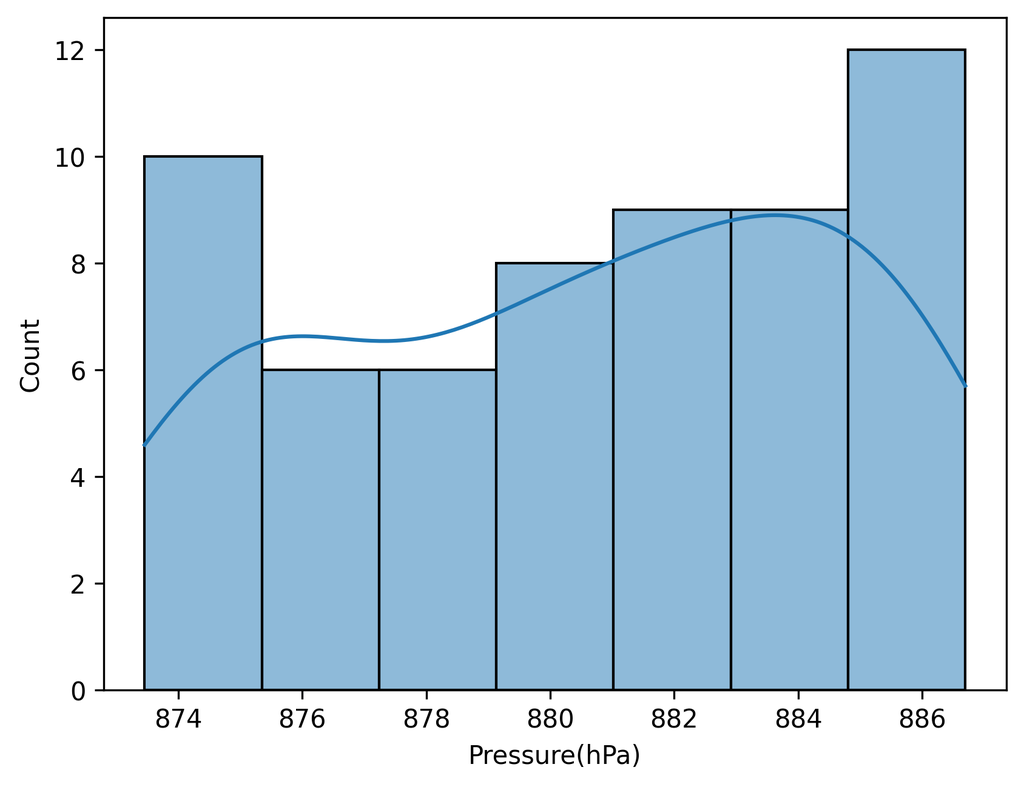

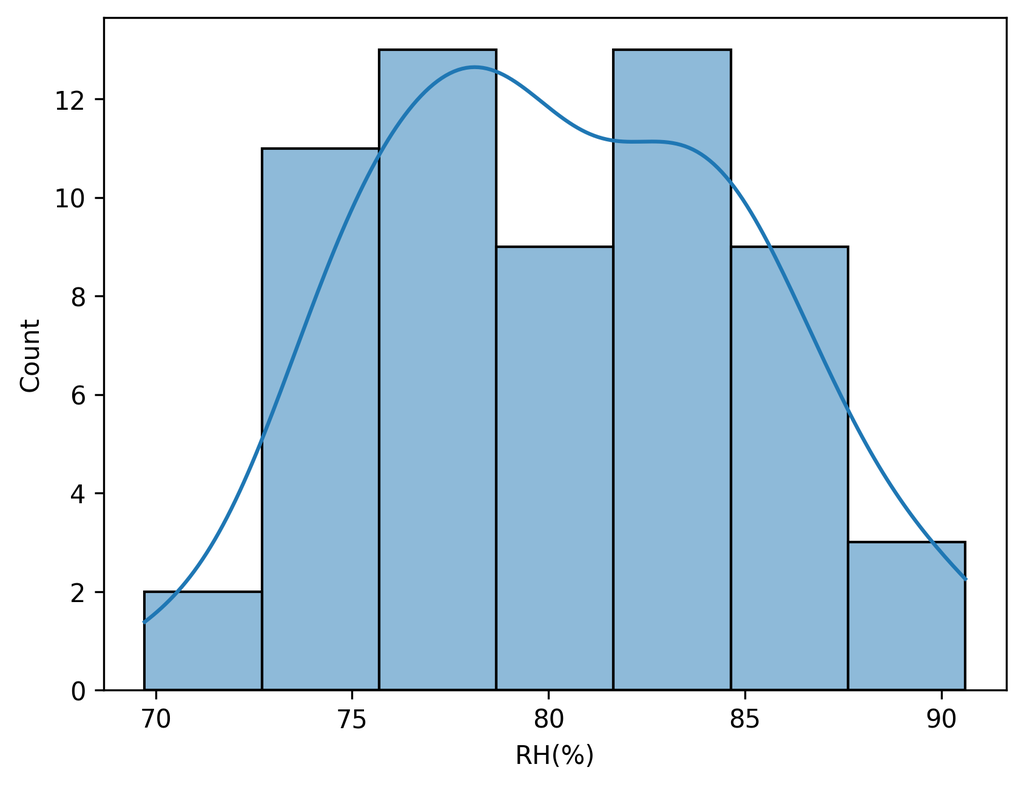

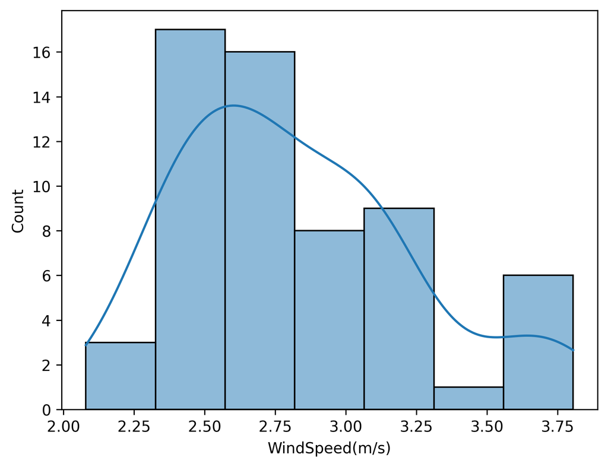

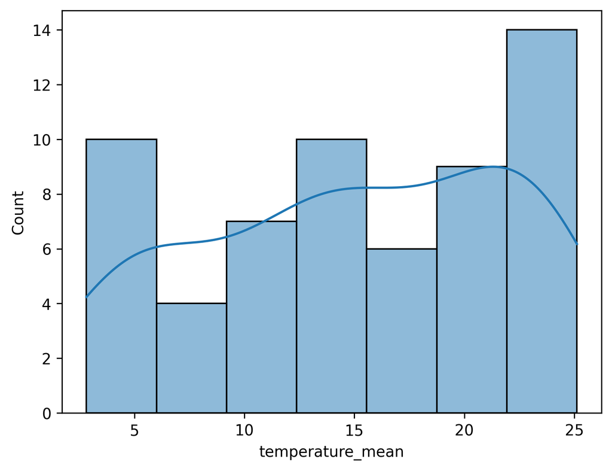

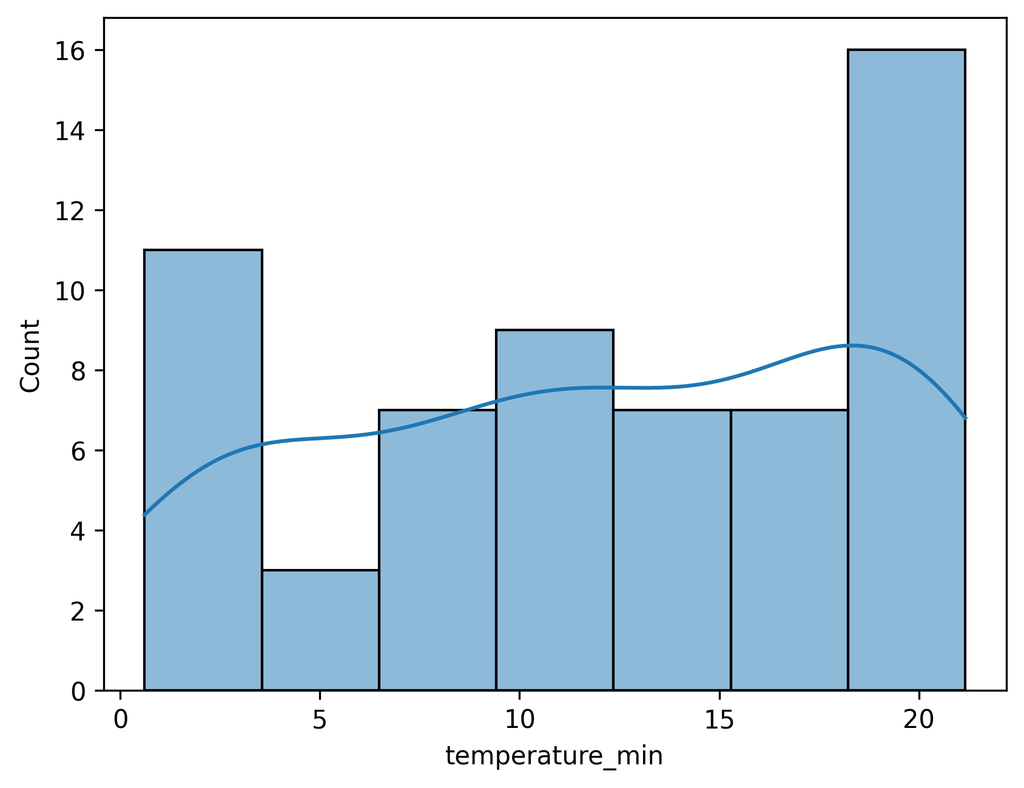

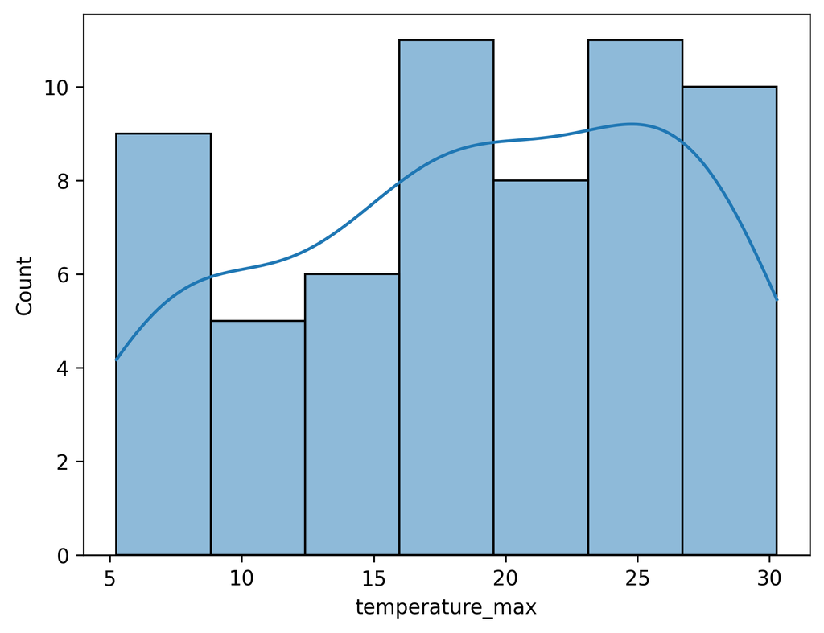

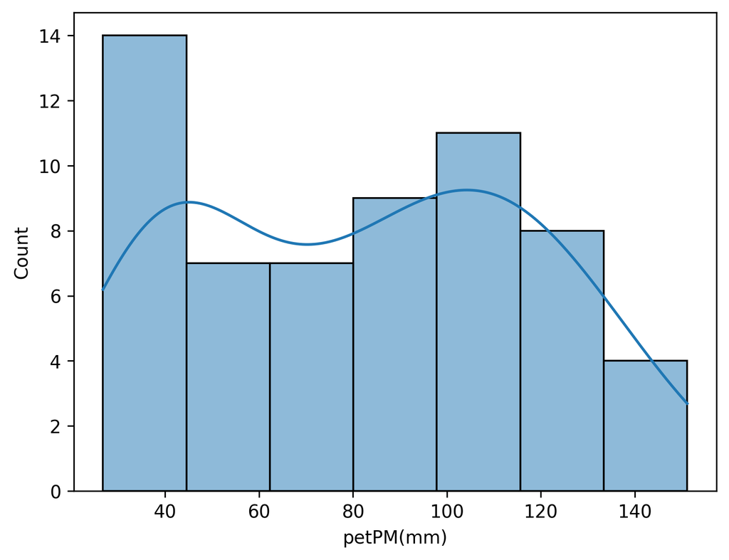

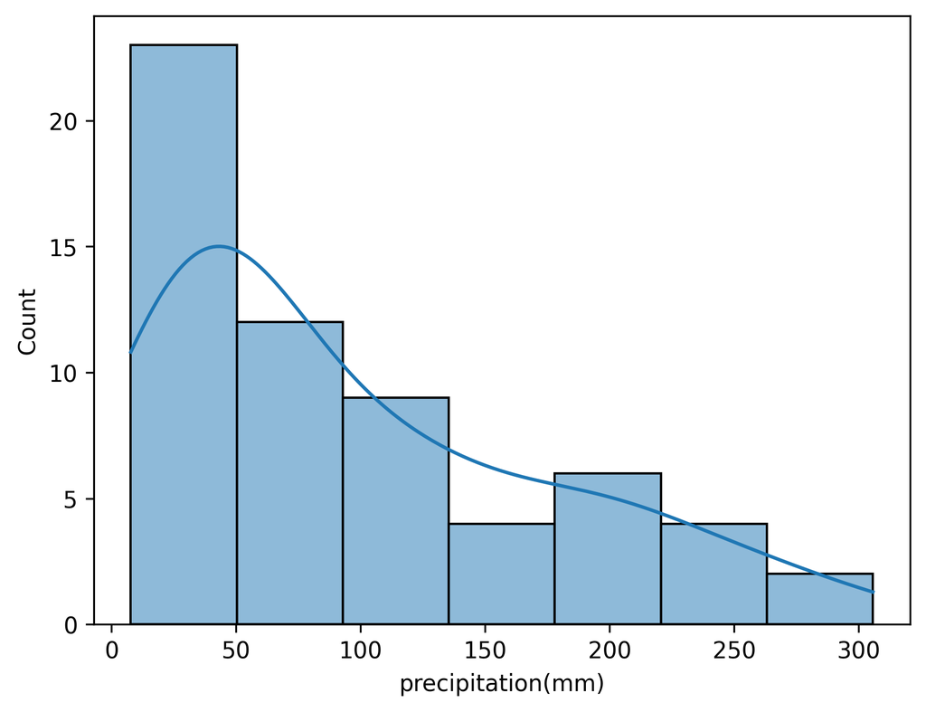

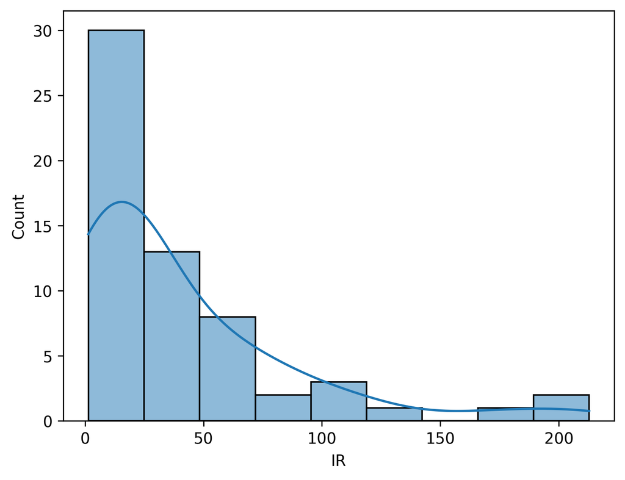

```python
#绘制气象数据分布直方图
import matplotlib.pyplot as plt
import seaborn as sns
for i in FeatureName:
    plt.figure(dpi=300)
    sns.histplot(data=Data.loc[:,i],kde=True)
    plt.show()
```

```python
import numpy as np
#对气象数据构造滞后变量（k=0,1,2）
def create_lag_variables(data, meteorological_cols, lag_orders=[0,1,2]):
    data_lag=data.copy()
    for col in meteorological_cols:
        for k in lag_orders:
            if k==0:    #滞后0阶
                data_lag[f"{col}_lag{k}"]=data_lag[col]
            else:     # 滞后k阶
                data_lag[f"{col}_lag{k}"]=data_lag[col].shift(k)
    #剔除滞后操作产生的缺失值
    data_lag=data_lag.dropna().reset_index(drop=True)
    #保留必要列（HFMD+所有滞后气象变量）
    keep_cols=['IR']+[col for col in data_lag.columns if '_lag' in col]
    data_lag=data_lag[keep_cols]
    return data_lag
```

```python
#构造滞后阶数
data_lag=create_lag_variables(data=Data, meteorological_cols=['Pressure(hPa)','RH(%)', 'WindSpeed(m/s)','temperature_mean',
                                                              'temperature_min', 'temperature_max', 'petPM(mm)','precipitation(mm)'], lag_orders=[0,1,2])
```

```python
#计算Spearman相关系数并进行Bonferroni校正
from scipy.stats import spearmanr
from statsmodels.stats.multitest import multipletests
def spearman_corr_with_bonferroni(data,hfmd_ir,meteorological_lag_cols):
    result_list = []
    for col in meteorological_lag_cols:
        # 提取对应数据
        x =data[col].dropna()
        y =data[hfmd_ir].reindex(x.index).dropna()
        spearman_corr,raw_p=spearmanr(x, y)
        result_list.append({'meteorological_lag_var': col,    #储存结果
                            'spearman_corr': spearman_corr,'raw_p_value': raw_p})
    #转换为DataFrame
    corr_result = pd.DataFrame(result_list)
    # Bonferroni校正
    rej, bonferroni_p,alphacSidak,alphacBonf=multipletests(corr_result['raw_p_value'], alpha=0.05, method='bonferroni')
    # 补充校正结果到DataFrame
    corr_result['bonferroni_p_value']=bonferroni_p
    corr_result['alphacSidak']=alphacSidak
    corr_result['alphacBonf']=alphacBonf
    corr_result['abs_spearman_corr']=abs(corr_result['spearman_corr'])
    corr_result['is_significant']=rej
    return corr_result
```

```python
#计算spearman相关系数
ClimateList=data_lag.columns[1:]
SpearmanResult=spearman_corr_with_bonferroni(data=data_lag,hfmd_ir='IR',meteorological_lag_cols=ClimateList)
```

```python
SpearmanResult.index=(list(SpearmanResult['meteorological_lag_var']))
```

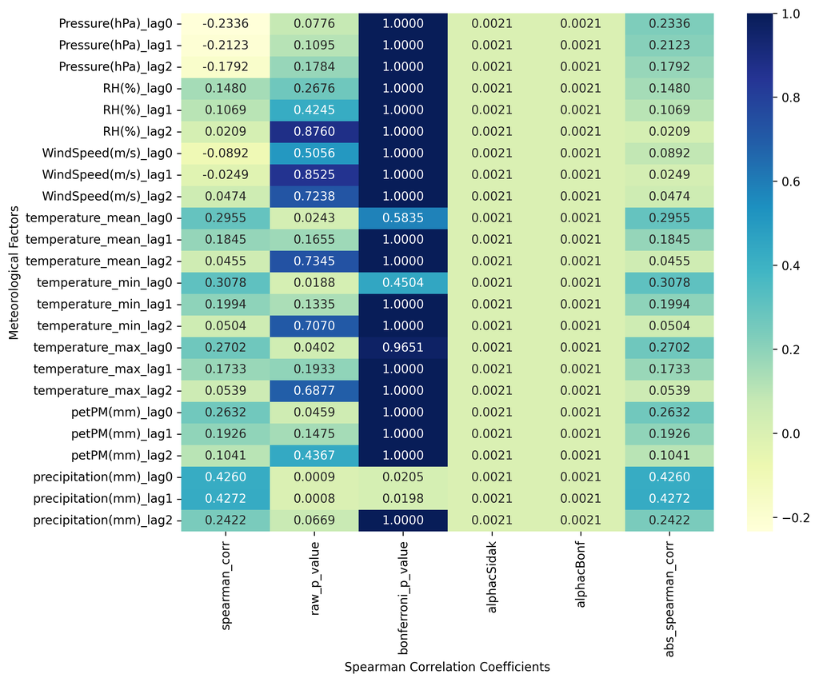

```python
import matplotlib.pyplot as plt
import seaborn as sns
#绘制热力图
plt.figure(figsize=(10, 8),dpi=300)
sns.heatmap(SpearmanResult.iloc[:,1:-1], annot=True, cmap="YlGnBu", fmt=".4f")
plt.title("")
plt.xlabel("Spearman Correlation Coefficients")
plt.ylabel("Meteorological Factors")
plt.tight_layout()
plt.show()
```

```python
#输出Spearman相关系数计算结果
SpearmanResult.to_csv('/root/ToResult/Stage2CorrelationAnalysis/SpearmanResult.csv',encoding='utf-8')
```

```python
#筛选显著且相关系数绝对值较大的最优滞后阶数
def select_optimal_lag_orders(corr_result, meteorological_cols):
    optimal_lag_result = {}
    for meteor in meteorological_cols:
        # 筛选该气象因素的所有滞后变量结果
        meteor_corr = corr_result[corr_result['meteorological_lag_var'].str.startswith(meteor)]
        # 第一步：筛选具有统计学意义的
        significant_corr = meteor_corr[meteor_corr['is_significant'] == True]
        if len(significant_corr) == 0:    # 无显著相关的滞后阶数
            optimal_lag_result[meteor] = {'optimal_lag': None,'max_abs_corr': None,'bonferroni_p': None,'is_significant': False}
            continue
        #选择相关系数绝对值最大的阶数
        max_abs_idx=significant_corr['abs_spearman_corr'].idxmax()
        max_abs_row=significant_corr.loc[max_abs_idx]
        # 提取最优滞后阶数
        lag_order = int(max_abs_row['meteorological_lag_var'].split('_lag')[-1])
        # 存入结果
        optimal_lag_result[meteor] = {'optimal_lag': lag_order,'max_abs_corr': max_abs_row['abs_spearman_corr'],
                                      'spearman_corr': max_abs_row['spearman_corr'],'bonferroni_p': max_abs_row['bonferroni_p_value'],
                                      'is_significant': True,'optimal_var': max_abs_row['meteorological_lag_var']}
    # 转换为DataFrame
    optimal_lag_df = pd.DataFrame(optimal_lag_result).T.reset_index()
    optimal_lag_df.rename(columns={'index': 'meteorological_factor'}, inplace=True)
    return optimal_lag_df, optimal_lag_result
```

```python
#提取最佳滞后阶数
optimal_lag_df,optimal_lag_dict=select_optimal_lag_orders(corr_result=SpearmanResult, meteorological_cols=ClimateList)
```

```python
# 提取有效最优滞后变量
valid_optimal_vars = [v['optimal_var'] for v in optimal_lag_dict.values() if v['is_significant']]
```

```python
# 计算方差膨胀因子并进行去除多重共线性
from statsmodels.stats.outliers_influence import variance_inflation_factor
from pandas import DataFrame
#计算VIF
def calculate_vif(data, features):
    X = data[features].copy()
    X['const'] = 1  # 添加常数项
    # 计算变量的VIF
    vif_list = []
    for col in features:
        vif=variance_inflation_factor(X.values, X.columns.get_loc(col))
        vif_list.append({'feature': col,'vif_value': vif})
    #转换为DataFrame
    vif_result=DataFrame(vif_list).sort_values(by='vif_value', ascending=False)
    return vif_result
#去除多重共线性项
def remove_multicollinearity(data, features, vif_threshold=10):
    final_features = features.copy()
    vif_history = []
    while True:
        #计算当前特征的VIF
        vif_df=calculate_vif(data, final_features)
        vif_history.append(vif_df)
        max_vif=vif_df['vif_value'].max()    #获取最大VIF值
        if max_vif>vif_threshold:
            # 剔除VIF最大的变量
            remove_feature=vif_df.iloc[0]['feature']
            final_features.remove(remove_feature)
            print(f"剔除多重共线性变量：{remove_feature}（VIF={max_vif:.2f} > {vif_threshold}）")
        else:    # 所有变量VIF≤阈值，停止循环
            break
    return final_features, vif_history
```

```python
#构造最优滞后变量的特征矩阵
df_features=data_lag[ClimateList].copy()
#计算VIF并剔除多重共线性
vif_threshold=10
final_valid_features,vif_history=remove_multicollinearity(data_lag,valid_optimal_vars, vif_threshold)
# 输出最终结果
print(f"初始有效滞后变量数：{len(valid_optimal_vars)}")
print(f"剔除后有效特征数：{len(final_valid_features)}")
print(f"最终气象变量特征列表：{final_valid_features}")
#输出最终特征的VIF值
final_vif=calculate_vif(data_lag, final_valid_features)
print(final_vif.round(4))
```

```
初始有效滞后变量数：2
剔除后有效特征数：2
最终气象变量特征列表：['precipitation(mm)_lag0', 'precipitation(mm)_lag1']
                  feature  vif_value
0  precipitation(mm)_lag0     1.2472
1  precipitation(mm)_lag1     1.2472
```

```python
#合并数据
Data['precipitation(mm)_lag1']=data_lag['precipitation(mm)_lag1']
```

```python
Data.fillna(0,inplace=True)
```

经过分析，气象因素与HFMD之间为非线性关系，使用GAM模型分析气象因素与HFMD之间为非线性关系。

```python
#拟合GAM模型
from pygam import PoissonGAM, s
Climate=['Pressure(hPa)', 'RH(%)', 'WindSpeed(m/s)','temperature_mean', 'temperature_min',
         'temperature_max', 'petPM(mm)','precipitation(mm)', 'precipitation(mm)_lag1']
X=Data[Climate].values    #构建拟合变量
y=Data['IR'].values
GAM=PoissonGAM(s(0)+s(1)+s(2) +s(3)+s(4)+s(5)+s(6)+s(7)+s(8))    #构建GAM模型
GAM.fit(X, y)
```

```
did not converge
```

```
PoissonGAM(callbacks=[Deviance(), Diffs()], fit_intercept=True,
   max_iter=100,
   terms=s(0) + s(1) + s(2) + s(3) + s(4) + s(5) + s(6) + s(7) + s(8) + intercept,
   tol=0.0001, verbose=False)
```

```python
#查看GAM模型摘要
import joblib
GAM=joblib.load('/root/ToResult/Stage2CorrelationAnalysis/GAMModelV1.joblib')
GAM.summary()
```

```
PoissonGAM
=============================================== ==========================================================
Distribution:                       PoissonDist Effective DoF:                                     47.5924
Link Function:                          LogLink Log Likelihood:                                  -178.1595
Number of Samples:                           60 AIC:                                              451.5038
                                                AICc:                                             914.5927
                                                UBRE:                                               5.3477
                                                Scale:                                                 1.0
                                                Pseudo R-Squared:                                   0.9744
==========================================================================================================
Feature Function                  Lambda               Rank         EDoF         P > x        Sig. Code
================================= ==================== ============ ============ ============ ============
s(0)                              [0.6]                20                        0.00e+00     ***
s(1)                              [0.6]                20                        0.00e+00     ***
s(2)                              [0.6]                20                        0.00e+00     ***
s(3)                              [0.6]                20                        0.00e+00     ***
s(4)                              [0.6]                20                        0.00e+00     ***
s(5)                              [0.6]                20                        0.00e+00     ***
s(6)                              [0.6]                20                        0.00e+00     ***
s(7)                              [0.6]                20                        0.00e+00     ***
s(8)                              [0.6]                20                        0.00e+00     ***
intercept                                              1                         0.00e+00     ***
==========================================================================================================
Significance codes:  0 '***' 0.001 '**' 0.01 '*' 0.05 '.' 0.1 ' ' 1

WARNING: Fitting splines and a linear function to a feature introduces a model identifiability problem
         which can cause p-values to appear significant when they are not.

WARNING: p-values calculated in this manner behave correctly for un-penalized models or models with
         known smoothing parameters, but when smoothing parameters have been estimated, the p-values
         are typically lower than they should be, meaning that the tests reject the null too readily.
```

```python
#保存GAM模型
import joblib
joblib.dump(GAM,'/root/ToResult/Stage2CorrelationAnalysis/GAMModelV1.joblib')
```

```
['/root/ToResult/Stage2CorrelationAnalysis/GAMModelV1.joblib']
```

拟合值 vs 残差图：判断残差是否随机分布（无明显趋势说明模型拟合良好）； 残差直方图 + QQ 图：判断残差是否符合模型假设（泊松模型残差应近似正态分布，无明显偏态）。

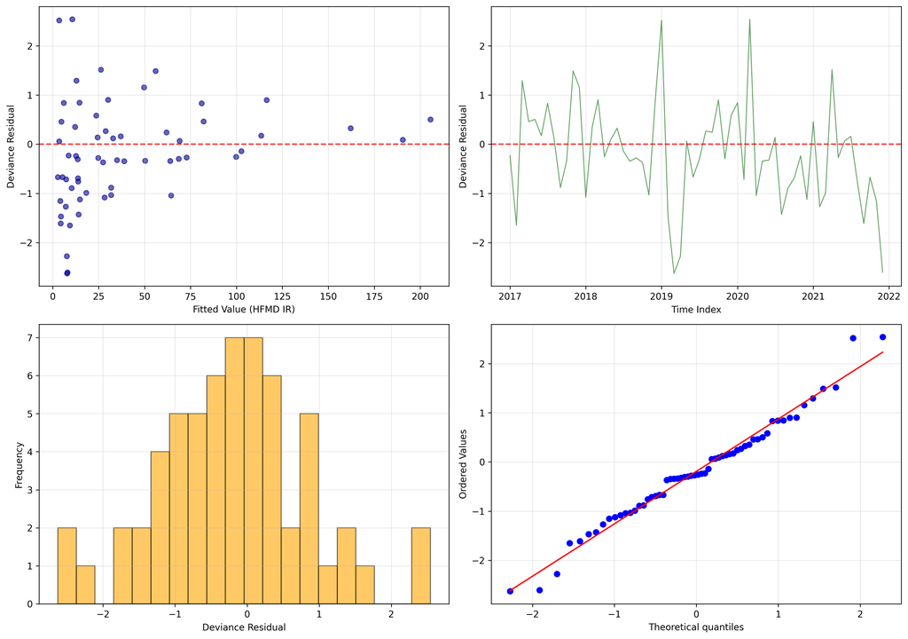

```python
#模型效果评估残差图
from scipy import stats
#计算模型残差,使用deviance残差
y_fit=GAM.predict(X)
residuals=GAM.deviance_residuals(X, y)
#绘制残差图
fig, axes = plt.subplots(2, 2, figsize=(14, 10),dpi=300)
# 子图1：拟合值 vs 残差
axes[0, 0].scatter(y_fit, residuals, color='darkblue', alpha=0.6, s=30)
axes[0, 0].axhline(y=0, color='red', linestyle='--', alpha=0.8)
axes[0, 0].set_xlabel('Fitted Value (HFMD IR)')
axes[0, 0].set_ylabel('Deviance Residual')
axes[0, 0].set_title('')
axes[0, 0].grid(alpha=0.3)
# 子图2：残差时间序列
axes[0, 1].plot(Data['Date'], residuals, color='darkgreen', alpha=0.6, linewidth=1)
axes[0, 1].axhline(y=0, color='red', linestyle='--', alpha=0.8)
axes[0, 1].set_xlabel('Time Index')
axes[0, 1].set_ylabel('Deviance Residual')
axes[0, 1].set_title('')
axes[0, 1].grid(alpha=0.3)
# 子图3：残差直方图
axes[1, 0].hist(residuals, bins=20, color='orange', alpha=0.6, edgecolor='black')
axes[1, 0].set_xlabel('Deviance Residual')
axes[1, 0].set_ylabel('Frequency')
axes[1, 0].set_title('')
axes[1, 0].grid(alpha=0.3)
# 子图4：残差QQ图（判断是否符合正态分布）
stats.probplot(residuals, dist="norm", plot=axes[1, 1])
axes[1, 1].set_title('')
axes[1, 1].grid(alpha=0.3)
plt.suptitle('', fontsize=16)
plt.tight_layout()
plt.show()
```

图1：偏差残差随机分布在 0附近，无明显的趋势或聚集模式，表明模型已充分捕捉了与“HFMD发病率拟合值” 相关的效应，没有遗漏系统偏差。 图2：残差随时间索引在0附近波动，无持续的趋势或周期性，表明模型已考虑了时间相关的效应，没有遗漏时间维度的系统信息。 图3：残差的直方图以0为峰值，左右分布相对对称，结合高斯核密度估计以及shapiro检验表明模型残差接近正态分布，符合 Poisson 模型的残差假设，没有明显的分布异常。 图4：大部分残差点紧密贴合红色参考线，仅尾部的少数点轻微偏离。残差的分位数与理论分位数拟合度较高，残差分布基本符合模型假设。

```
GAM模型残差正态检验统计量:0.981757947215075,P值:0.5072625761637939
```

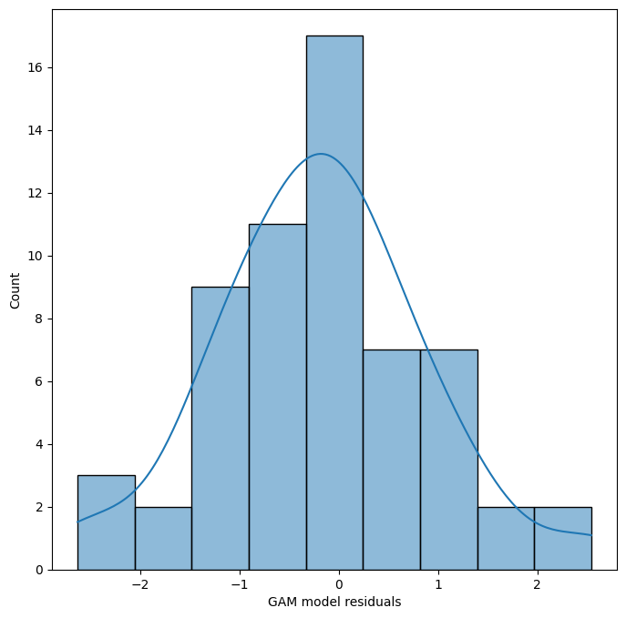

```python
#对残差进行正态检验
resid_stats,resid_pavlue=shapiro(residuals)
print(f'GAM模型残差正态检验统计量:{resid_stats},P值:{resid_pavlue}')
plt.figure(figsize=(8,8))
sns.histplot(data=residuals,kde=True)
plt.xlabel('GAM model residuals')
plt.show()
```

```python
# 过离散检验：皮尔逊残差方差
# 泊松模型假设「方差=均值」，若残差方差远大于1，说明存在过离散
y_pred=GAM.predict(X)
pearson_resid=(y-y_pred)/np.sqrt(y_pred)  # 皮尔逊残差
overdispersion=np.var(pearson_resid)
print(f"皮尔逊残差方差（过离散检验）:{overdispersion:.4f}")
if overdispersion > 1.5:
    print("数据存在明显过离散，建议更换为负二项GAM")
else:
    print("数据无明显过离散，泊松GAM拟合效果稳健")
```

```
皮尔逊残差方差（过离散检验）:1.0530
数据无明显过离散，泊松GAM拟合效果稳健
```

```python
# 各气象因素显著性判断
feature_gam,pvalue_gam=[],[]
for i, term in enumerate(Climate):
    # 基于卡方检验计算平滑项的p值
    p_value =GAM.statistics_['p_values'][i]
    feature_gam.append(term)
    pvalue_gam.append(p_value)
GAMSign=DataFrame()
GAMSign['Feature']=feature_gam
GAMSign['Pvalue']=pvalue_gam
```

```python
GAMSign
```

|  | Feature | Pvalue |
| --- | --- | --- |
| 0 | Pressure(hPa) | 0.0 |
| 1 | RH(%) | 0.0 |
| 2 | WindSpeed(m/s) | 0.0 |
| 3 | temperature_mean | 0.0 |
| 4 | temperature_min | 0.0 |
| 5 | temperature_max | 0.0 |
| 6 | petPM(mm) | 0.0 |
| 7 | precipitation(mm) | 0.0 |
| 8 | precipitation(mm)_lag1 | 0.0 |

```python
#输出检验结果
GAMSign.to_csv('/root/ToResult/Stage2CorrelationAnalysis/GAMSignResult.csv',encoding='utf-8')
```

```python
#绘制气象因素与HFMD的平滑曲线
def plot_gam_smooth_curve(gam, X, feature_idx, feature_name, ax):
    feature_vals=X[:, feature_idx]
    x_grid=np.linspace(feature_vals.min(), feature_vals.max(), 100)
    #构造其他变量为均值
    X_grid=np.ones((100, X.shape[1]))*np.mean(X,axis=0)
    X_grid[:,feature_idx]=x_grid  # 仅当前特征变化，其他特征固定为均值
    # 预测部分效应（链接函数为log，转换为原始尺度的效应）
    y_grid, y_grid_ci=gam.partial_dependence(feature_idx, X=X_grid, width=0.95)  # 95%置信区间
    # 绘制平滑曲线和置信区间
    ax.plot(x_grid, y_grid, color='darkred', linewidth=2.5, label=f'{feature_name} Smooth Trend')
    ax.fill_between(x_grid, y_grid_ci[:, 0], y_grid_ci[:, 1], color='blue', alpha=0.3, label='95% CI')
    # 绘制0值参考线（效应是否显著的分界）
    ax.axhline(y=0, color='black', linestyle='--', alpha=0.7)
    ax.set_xlabel(feature_name)
    ax.set_ylabel('Partial Effect (Log Scale)')
    ax.set_title(f'Smooth Curve: {feature_name} vs HFMD')
    ax.grid(alpha=0.3)
    ax.legend()
    return x_grid,y_grid, y_grid_ci
```

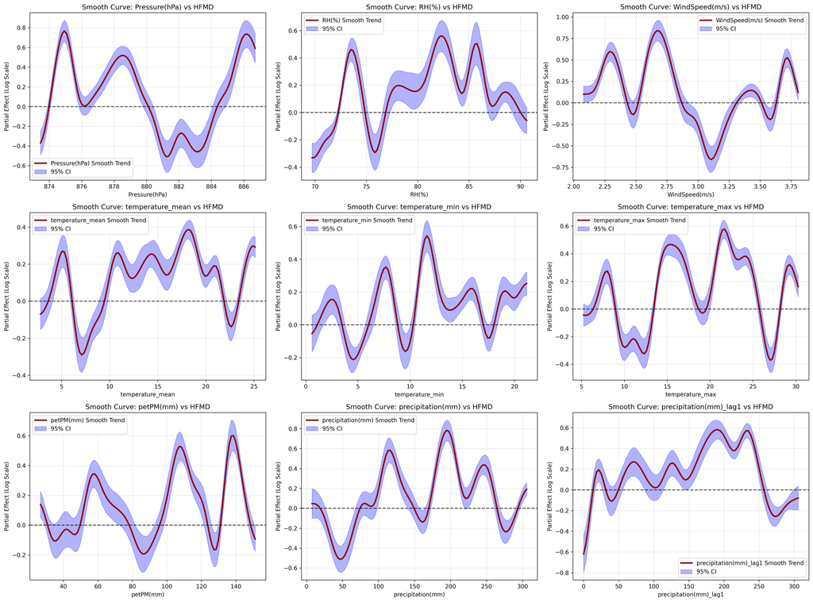

```python
#记录偏效应
ClimateName,ClimateIndex,ClimatePDP,ClimatePDPCI=[],[],[],[]
# 定义气象因素名称列表
climate_names = ['Pressure(hPa)','RH(%)','WindSpeed(m/s)','temperature_mean','temperature_min','temperature_max','petPM(mm)','precipitation(mm)','precipitation(mm)_lag1']
#绘制平滑曲线
fig, axes = plt.subplots(3, 3, figsize=(20,15),dpi=300)
axes = axes.flatten()
for i, full_name in enumerate(climate_names):
    X_grid,y_grid, y_grid_ci=plot_gam_smooth_curve(GAM, X, i, full_name, axes[i])
    ClimateName.append(climate_names)
    ClimateIndex.append(X_grid)
    ClimatePDP.append(y_grid)
    ClimatePDPCI.append(y_grid_ci)
plt.suptitle('', fontsize=16)
plt.tight_layout()
plt.show()
```

```python
#计算风险比(RR)
def ComputerRR(climate_names):
    for i,climate in enumerate(climate_names):
        RRData=DataFrame()
        climateindex=ClimateIndex[i]
        PDP=ClimatePDP[i]
        PDPCI=ClimatePDPCI[i]
        RR=np.exp(PDP)
        RRCI=np.exp(PDPCI)
        RRData['index']=climateindex
        RRData['PDP']=PDP
        RRData['PDP 95CI']=list(PDPCI)
        RRData['RR']=RR
        RRData['RR 95CI']=list(RRCI)
        RRData.to_csv('/root/ToResult/Stage2CorrelationAnalysis/'+climate+'PDPRR'+'.csv')
```

```python
ComputerRR(climate_names=['Pressure(hPa)','RH(%)','WindSpeed(ms)','temperature_mean','temperature_min','temperature_max','petPM(mm)','precipitation(mm)','precipitation(mm)_lag1'])
```

```python
import pandas as pd
import numpy as np
import statsmodels.api as sm
df=Data.copy()    #复制数据
# 气压（Pressure）：双分段点（878、882hPa）
df['press_cut1']=(df['Pressure(hPa)'] >= 878).astype(int)  # 分段点1
df['press_cut2']=(df['Pressure(hPa)'] >= 882).astype(int)  # 分段点2
df['press_inter1']=df['Pressure(hPa)'] * df['press_cut1']  # 交互项1
df['press_inter2']=df['Pressure(hPa)'] * df['press_cut2']  # 交互项2
# 相对湿度（RH）：双分段点（75%、80%）
df['rh_cut1'] = (df['RH(%)'] >= 75).astype(int)
df['rh_cut2'] = (df['RH(%)'] >= 80).astype(int)
df['rh_inter1'] = df['RH(%)'] * df['rh_cut1']
df['rh_inter2'] = df['RH(%)'] * df['rh_cut2']
# 风速（WindSpeed）：双分段点（2.5、3.0m/s）
df['wind_cut1'] = (df['WindSpeed(m/s)'] >= 2.5).astype(int)
df['wind_cut2'] = (df['WindSpeed(m/s)'] >= 3.0).astype(int)
df['wind_inter1'] = df['WindSpeed(m/s)'] * df['wind_cut1']
df['wind_inter2'] = df['WindSpeed(m/s)'] * df['wind_cut2']
#温度均值（temperature_mean）：多分段点（5、10、15℃）
df['temp_mean_cut1'] = (df['temperature_mean'] >= 5).astype(int)
df['temp_mean_cut2'] = (df['temperature_mean'] >= 10).astype(int)
df['temp_mean_cut3'] = (df['temperature_mean'] >= 15).astype(int)
df['temp_mean_inter1'] = df['temperature_mean'] * df['temp_mean_cut1']
df['temp_mean_inter2'] = df['temperature_mean'] * df['temp_mean_cut2']
df['temp_mean_inter3'] = df['temperature_mean'] * df['temp_mean_cut3']
#温度最小值（temperature_min）：多分段点（5、10、15℃）
df['temp_min_cut1'] = (df['temperature_min'] >= 5).astype(int)
df['temp_min_cut2'] = (df['temperature_min'] >= 10).astype(int)
df['temp_min_cut3'] = (df['temperature_min'] >= 15).astype(int)
df['temp_min_inter1'] = df['temperature_min'] * df['temp_min_cut1']
df['temp_min_inter2'] = df['temperature_min'] * df['temp_min_cut2']
df['temp_min_inter3'] = df['temperature_min'] * df['temp_min_cut3']
#温度最大值（temperature_max）：多分段点（5、10、15℃）
df['temp_max_cut1'] = (df['temperature_max'] >= 5).astype(int)
df['temp_max_cut2'] = (df['temperature_max'] >= 10).astype(int)
df['temp_max_cut3'] = (df['temperature_max'] >= 15).astype(int)
df['temp_max_inter1'] = df['temperature_max'] * df['temp_max_cut1']
df['temp_max_inter2'] = df['temperature_max'] * df['temp_max_cut2']
df['temp_max_inter3'] = df['temperature_max'] * df['temp_max_cut3']
# petPM：双分段点（ 60mm、100mm）
df['petPM_cut1'] = (df['petPM(mm)'] >= 75).astype(int)
df['petPM_cut2'] = (df['petPM(mm)'] >= 80).astype(int)
df['petPM_inter1'] = df['petPM(mm)'] * df['petPM_cut1']
df['petPM_inter2'] = df['petPM(mm)'] * df['petPM_cut2']
# 降水量（precipitation）：二次项+分段点（150mm）
df['precip_sq'] = df['precipitation(mm)'] ** 2  # 二次项（捕捉先升后降）
df['precip_cut'] = (df['precipitation(mm)'] >= 150).astype(int)
df['precip_inter'] = df['precipitation(mm)'] * df['precip_cut']
#滞后1期降水量（precipitation_lag1）：二次项+分段点（100mm）
df['precip_lag1_sq'] = df['precipitation(mm)_lag1'] ** 2
df['precip_lag1_cut'] = (df['precipitation(mm)_lag1'] >= 100).astype(int)
df['precip_lag1_inter'] = df['precipitation(mm)_lag1'] * df['precip_lag1_cut']
```

```python
#构建拟合变量
X_glm=df[
    # 气压扩展项
    ['Pressure(hPa)', 'press_cut1', 'press_cut2', 'press_inter1', 'press_inter2',
     # 相对湿度扩展项
     'RH(%)', 'rh_cut1', 'rh_cut2', 'rh_inter1', 'rh_inter2',
     # 风速扩展项
     'WindSpeed(m/s)', 'wind_cut1', 'wind_cut2', 'wind_inter1', 'wind_inter2',
     # 温度均值扩展项
     'temperature_mean', 'temp_mean_cut1', 'temp_mean_cut2', 'temp_mean_cut3',
     'temp_mean_inter1', 'temp_mean_inter2', 'temp_mean_inter3',
     # 温度最小值扩展项
     'temperature_min', 'temp_min_cut1', 'temp_min_cut2', 'temp_min_cut3',
     'temp_min_inter1', 'temp_min_inter2', 'temp_min_inter3',
     # 温度最大值扩展项
     'temperature_max', 'temp_max_cut1', 'temp_max_cut2', 'temp_max_cut3',
     'temp_max_inter1', 'temp_max_inter2', 'temp_max_inter3',
     # petPM扩展项
     'petPM(mm)','petPM_cut1','petPM_cut2','petPM_inter1','petPM_inter2',
     # 降水量扩展项
     'precipitation(mm)', 'precip_sq', 'precip_cut', 'precip_inter',
     # 滞后1期降水量扩展项
     'precipitation(mm)_lag1', 'precip_lag1_sq', 'precip_lag1_cut', 'precip_lag1_inter']
]
X_glm=sm.add_constant(X_glm)
y_glm=df['IR']
```

```python
glm_family=sm.families.Poisson(link=sm.families.links.log())
extended_glm=sm.GLM(y_glm, X_glm, family=glm_family)
glm_results=extended_glm.fit()
# 输出模型摘要
print(glm_results.summary())
```

```
                 Generalized Linear Model Regression Results
==============================================================================
Dep. Variable:                     IR   No. Observations:                   60
Model:                            GLM   Df Residuals:                       12
Model Family:                 Poisson   Df Model:                           47
Link Function:                    log   Scale:                          1.0000
Method:                          IRLS   Log-Likelihood:                -279.46
Date:                Fri, 15 May 2026   Deviance:                       269.66
Time:                        10:42:22   Pearson chi2:                     258.
No. Iterations:                     6   Pseudo R-squ. (CS):              1.000
Covariance Type:            nonrobust
==========================================================================================
                             coef    std err          z      P>|z|      [0.025      0.975]
------------------------------------------------------------------------------------------
Pressure(hPa)              0.4155      0.075      5.523      0.000       0.268       0.563
press_cut1               759.2661    117.398      6.467      0.000     529.170     989.362
press_cut2              -629.2072    119.234     -5.277      0.000    -862.902    -395.512
press_inter1              -0.8628      0.134     -6.460      0.000      -1.125      -0.601
press_inter2               0.7120      0.135      5.266      0.000       0.447       0.977
RH(%)                      0.1625      0.121      1.344      0.179      -0.075       0.400
rh_cut1                   24.9118      7.812      3.189      0.001       9.600      40.223
rh_cut2                    5.3707      6.605      0.813      0.416      -7.575      18.317
rh_inter1                 -0.3245      0.105     -3.090      0.002      -0.530      -0.119
rh_inter2                 -0.0420      0.083     -0.507      0.612      -0.204       0.120
WindSpeed(m/s)             5.7487      1.111      5.177      0.000       3.572       7.925
wind_cut1                 13.3358      3.762      3.545      0.000       5.963      20.708
wind_cut2                 -0.1860      2.528     -0.074      0.941      -5.140       4.768
wind_inter1               -5.5851      1.562     -3.575      0.000      -8.647      -2.523
wind_inter2               -0.3762      0.930     -0.405      0.686      -2.199       1.447
temperature_mean           0.6408      1.384      0.463      0.643      -2.071       3.353
temp_mean_cut1            12.3812      3.878      3.193      0.001       4.781      19.982
temp_mean_cut2           -33.0195     11.615     -2.843      0.004     -55.785     -10.254
temp_mean_cut3            35.3924      6.060      5.840      0.000      23.515      47.270
temp_mean_inter1          -2.2610      0.661     -3.422      0.001      -3.556      -0.966
temp_mean_inter2           3.3638      1.160      2.900      0.004       1.091       5.637
temp_mean_inter3          -2.2022      0.390     -5.653      0.000      -2.966      -1.439
temperature_min           -0.6708      0.813     -0.825      0.409      -2.264       0.922
temp_min_cut1              2.1402      4.273      0.501      0.616      -6.235      10.516
temp_min_cut2             -6.0941      4.513     -1.350      0.177     -14.940       2.752
temp_min_cut3            -20.9170      3.528     -5.929      0.000     -27.832     -14.002
```

[output cut: 9 more lines]

```
temp_max_inter3           -2.6390      0.413     -6.385      0.000      -3.449      -1.829
petPM(mm)                 -0.1967      0.037     -5.380      0.000      -0.268      -0.125
petPM_cut1                21.4893     20.572      1.045      0.296     -18.831      61.810
petPM_cut2               -45.0533     20.984     -2.147      0.032     -86.181      -3.925
petPM_inter1              -0.2815      0.270     -1.041      0.298      -0.812       0.249
petPM_inter2               0.5846      0.274      2.131      0.033       0.047       1.122
precipitation(mm)          0.0277      0.008      3.462      0.001       0.012       0.043
precip_sq                 -0.0002   4.48e-05     -3.883      0.000      -0.000   -8.62e-05
precip_cut                -7.5099      1.634     -4.597      0.000     -10.712      -4.308
precip_inter               0.0497      0.012      4.214      0.000       0.027       0.073
precipitation(mm)_lag1     0.0117      0.005      2.300      0.021       0.002       0.022
precip_lag1_sq         -3.623e-05   2.67e-05     -1.357      0.175   -8.85e-05    1.61e-05
precip_lag1_cut            0.7620      1.090      0.699      0.484      -1.374       2.898
precip_lag1_inter         -0.0003      0.010     -0.028      0.978      -0.019       0.019
==========================================================================================
```

```python
#保存模型
joblib.dump(extended_glm,'/root/ToResult/Stage2CorrelationAnalysis/GLMModelV1.joblib')
```

```
['/root/ToResult/Stage2CorrelationAnalysis/GLMModelV1.joblib']
```

```python
#提取模型参数
coef_df = pd.DataFrame({
    'feature': glm_results.params.index,
    'coefficient estimate':glm_results.params.values,
    'standard error':glm_results.bse.values,
    'Z stats':glm_results.tvalues.values,  # GLM中t值等价于Z值
    'P value':glm_results.pvalues.values,
    '95%CI low':glm_results.conf_int()[0].values,
    '95%CI up':glm_results.conf_int()[1].values
})
#提取模型整体拟合参数
model_params = {
    'Pseudo R² (Explanatory Bias Ratio)': 1 - (glm_results.deviance /glm_results.null_deviance),
    'Zero bias (intercept model only)':glm_results.null_deviance,
    'Residual bias (extended GLM model)':glm_results.deviance,
    'AIC':glm_results.aic,
    'BIC':glm_results.bic,  # 模型复杂度惩罚更严格
    'N-sample':glm_results.nobs,
    'Pearson residual variance (overdispersion test)': np.var(glm_results.resid_pearson)
}
```

```python
#输出GLM模型拟合结果
coef_df.to_csv('/root/ToResult/Stage2CorrelationAnalysis/GLMResult.csv',encoding='utf-8')
```

```python
model_params
```

```
{'Pseudo R² (Explanatory Bias Ratio)': np.float64(0.8978628999342798),
 'Zero bias (intercept model only)': np.float64(2640.1579131180115),
 'Residual bias (extended GLM model)': np.float64(269.65807296143737),
 'AIC': np.float64(654.9115919427325),
 'BIC': np.float64(220.52593821477217),
 'N-sample': 60,
 'Pearson residual variance (overdispersion test)': np.float64(4.299831428931962)}
```

```python
#伪R²（解释偏差比例）
null_deviance=glm_results.null_deviance
residual_deviance=glm_results.deviance
pseudo_r2=1-(residual_deviance/null_deviance)
print(f"GLM伪R²:{pseudo_r2:.4f}")
#过离散检验：皮尔逊残差方差
pearson_resid=glm_results.resid_pearson
overdispersion=np.var(pearson_resid)
print(f"GLM皮尔逊残差方差：{overdispersion:.4f}")
```

```
GLM伪R²:0.8979
GLM皮尔逊残差方差：4.2998
```

```python
# 拟合优度深化（偏差减少比例）
deviance_reduction=(glm_results.null_deviance-glm_results.deviance)/glm_results.null_deviance*100
print(f"偏差减少比例：{deviance_reduction:.2f}%（模型相比仅截距模型，解释了{deviance_reduction:.2f}%的响应变量变异）")
# 预测精度评估
y_true=df['IR'].values
y_pred=glm_results.fittedvalues.values
# 计算常用预测误差指标
mae=np.mean(np.abs(y_true - y_pred))  # 平均绝对误差
mse = np.mean((y_true - y_pred) ** 2)   # 均方误差
rmse = np.sqrt(mse)                     # 均方根误差
mean_true = np.mean(y_true)
mape = np.mean(np.abs((y_true - y_pred) / y_true)) * 100  # 平均绝对百分比误差（避免0值报错可加微小常数）
print(f"平均绝对误差（MAE）：{mae:.4f}（平均每个样本预测误差为{mae:.4f}例）")
print(f"均方根误差（RMSE）：{rmse:.4f}")
print(f"平均绝对百分比误差（MAPE）：{mape:.2f}%")
print(f"真实值均值：{mean_true:.4f}（对比MAE，判断误差相对大小）")
```

```
偏差减少比例：89.79%（模型相比仅截距模型，解释了89.79%的响应变量变异）
平均绝对误差（MAE）：9.5942（平均每个样本预测误差为9.5942例）
均方根误差（RMSE）：12.5535
平均绝对百分比误差（MAPE）：73.09%
真实值均值：39.7659（对比MAE，判断误差相对大小）
```

```python
# 残差分析
fig, axes = plt.subplots(2, 2, figsize=(12, 10))
fig.suptitle("Extended GLM model performance visualisation evaluation", fontsize=14)
#残差 vs 拟合值
axes[0,0].scatter(glm_results.fittedvalues, glm_results.resid_deviance, alpha=0.5)
axes[0,0].axhline(y=0, color='red', linestyle='--')
axes[0,0].set_xlabel("fitted value")
axes[0,0].set_ylabel("bias residual")
#残差时间序列
axes[0,1].plot(df['Date'], glm_results.resid_deviance, color='green')
axes[0,1].axhline(y=0, color='red', linestyle='--')
axes[0,1].set_xlabel("Date")
axes[0,1].set_ylabel("bias residual")
#残差直方图
axes[1,0].hist(glm_results.resid_deviance, bins=15, color='orange')
axes[1,0].set_xlabel("bias residual")
axes[1,0].set_ylabel("Count")
#残差Q-Q图
qqplot(glm_results.resid_deviance, line='s', ax=axes[1,1])
axes[1,1].set_title("Q-Q plot of residuals")
plt.tight_layout()
plt.show()
```

[output not shown]

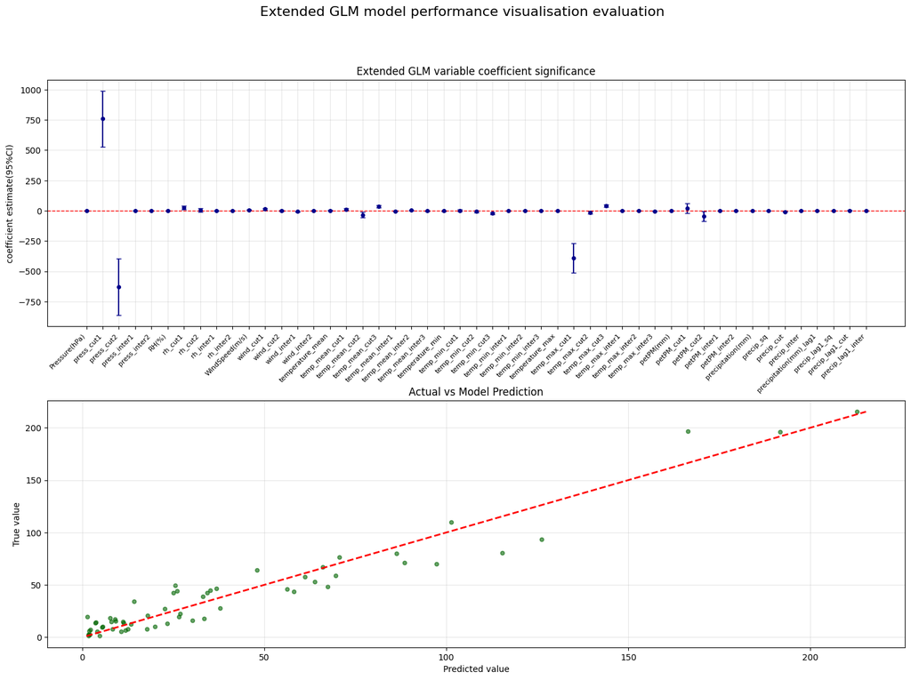

```python
import matplotlib.pyplot as plt
from statsmodels.graphics.gofplots import qqplot
# 构建图形画布（2行3列，覆盖核心可视化需求）
fig = plt.figure(figsize=(18, 12))
gs = fig.add_gridspec(2, 1, hspace=0.3, wspace=0.3)
#变量系数+95%置信区间
ax1 = fig.add_subplot(gs[0, 0])
# 选取前个显著变量
top_vars = coef_df.head(49)
x_pos = np.arange(len(top_vars))
ax1.errorbar(x_pos, top_vars['coefficient estimate'],
             yerr=[top_vars['coefficient estimate'] - top_vars['95%CI low'],
                   top_vars['95%CI up'] - top_vars['coefficient estimate']],
             fmt='o', color='darkblue', capsize=3, markersize=4)
ax1.axhline(y=0, color='red', linestyle='--', linewidth=1)
ax1.set_xticks(x_pos)
ax1.set_xticklabels(top_vars['feature'], rotation=45, ha='right', fontsize=8)
ax1.set_ylabel('coefficient estimate(95%CI)')
ax1.set_title('Extended GLM variable coefficient significance')
ax1.grid(alpha=0.3, linestyle='-')
#实际值vs预测值散点图
ax2 = fig.add_subplot(gs[1,0])
ax2.scatter(y_true, y_pred, alpha=0.6, color='darkgreen', s=20)
# 添加参考线（y=x）
min_val = min(min(y_true), min(y_pred))
max_val = max(max(y_true), max(y_pred))
ax2.plot([min_val, max_val], [min_val, max_val], 'r--', linewidth=2)
ax2.set_xlabel('Predicted value')
ax2.set_ylabel('True value')
ax2.set_title('Actual vs Model Prediction')
ax2.grid(alpha=0.3, linestyle='-')
# 整体标题
fig.suptitle('Extended GLM model performance visualisation evaluation', fontsize=16)
plt.show()
```

```python
from sklearn.metrics import r2_score
R2_GLM=r2_score(y_true, y_pred)
print(f'GLM模型R2:{R2_GLM}')
```

```
GLM模型R2:0.9271588254727923
```